# Лабораторная работа №9

Операционные системы

Краснова К. Г.

Российский университет дружбы народов, Москва, Россия

10 апрель 2025

## Цель работы

Целью данной дабораторной работы является освоение основных возможностей командной оболочки Midnight Commander. Приобретение навыков практической работы по просмотру каталогов и файлов; манипуляций с ними.

## Задание по mc

1. Изучите информацию о mc, вызвав в командной строке man mc.
2. Запустите из командной строки mc, изучите его структуру и меню.
3. Выполните несколько операций в mc, используя управляющие клавиши (операции с панелями; выделение/отмена выделения файлов, копирование/перемещение файлов, получение информации о размере и правах доступа на файлы и/или каталоги и т.п.)
4. Выполните основные команды меню левой (или правой) панели. Оцените степень подробности вывода информации о файлах.
5. Используя возможности подменю Файл , выполните:
- просмотр содержимого текстового файла;
- редактирование содержимого текстового файла (без сохранения результатов редактирования);
- создание каталога;
- копирование в файлов в созданный каталог.
6. С помощью соответствующих средств подменю Команда осуществите:
- поиск в файловой системе файла с заданными условиями (например, файла с расширением .c или .cpp, содержащего строку main);
- выбор и повторение одной из предыдущих команд;
- переход в домашний каталог;
- анализ файла меню и файла расширений.
7. Вызовите подменю Настройки . Освойте операции, определяющие структуру экрана mc (Full screen, Double Width, Show Hidden Files и т.д.)

## Задание по встроенному редактору mc

1. Создайте текстовой файл text.txt.
2. Откройте этот файл с помощью встроенного в mc редактора.
3. Вставьте в открытый файл небольшой фрагмент текста, скопированный из любого другого файла или Интернета.
4. Проделайте с текстом следующие манипуляции, используя горячие клавиши:
- Удалите строку текста.
- Выделите фрагмент текста и скопируйте его на новую строку
- Выделите фрагмент текста и перенесите его на новую строку.
- Сохраните файл.
- Отмените последнее действие.
- Перейдите в конец файла (нажав комбинацию клавиш) и напишите некоторый текст.
- Перейдите в начало файла (нажав комбинацию клавиш) и напишите некоторый текст. 4.8. Сохраните и закройте файл.
5. Откройте файл с исходным текстом на некотором языке программирования (напри- мер C или Java)
6. Используя меню редактора, включите подсветку синтаксиса, если она не включена, или выключите, если она включена

## Теоретическое введение

Командная оболочка — интерфейс взаимодействия пользователя с операционной систе- мой и программным обеспечением посредством команд. Midnight Commander (или mc) — псевдографическая командная оболочка для UNIX/Linux систем. Для запуска mc необходимо в командной строке набрать mc и нажать Enter . Рабочее пространство mc имеет две панели, отображающие по умолчанию списки файлов двух каталогов. Панель в mc отображает список файлов текущего каталога. Абсолютный путь к этому каталогу отображается в заголовке панели. У активной панели заголовок и одна из её строк подсвечиваются. Управление панелями осуществляется с помощью определённых комбинаций клавиш или пунктов меню mc. Панели можно поменять местами. Для этого и используется комбинация клавиш Ctrl-u или команда меню mc Переставить панели . Также можно временно убрать отображение панелей (отключить их) с помощью комбинации клавиш Ctrl-o или команды меню mc Отключить панели . Это может быть полезно, например, если необходимо увидеть вывод какой-то информации на экран после выполнения какой-либо команды shell

## Выполнение лабораторной работы

Изучаю информацию о mc (рис. 1).

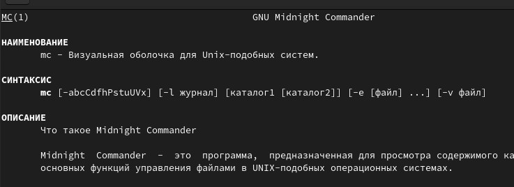

Информация о mc

## Выполнение лабораторной работы

Запускаю из командной строки mc (рис. 2).

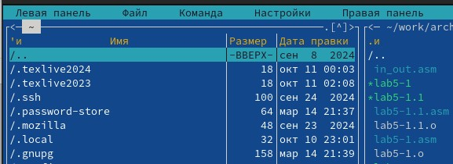

Запуск mc

## Выполнение лабораторной работы

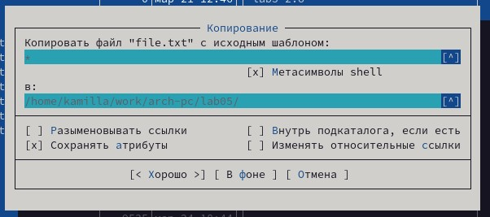

Копирование файла

## Выполнение лабораторной работы

С помощью F8 удаляю файл (рис. 4).

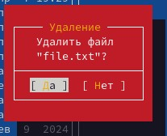

Удаление файла

## Выполнение лабораторной работы

Выполняю основные команды правой панели. Информация о файлах подробнее, чем с вызовом ls (рис. 5).

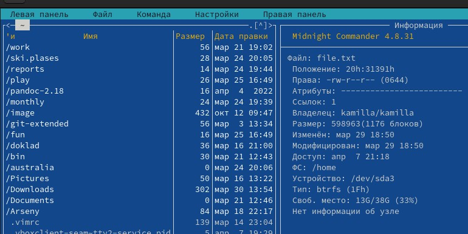

Меню правой панели

## Выполнение лабораторной работы

Используя возможности подменю Файл, просматриваю содержимое текстового файла (рис. 6).

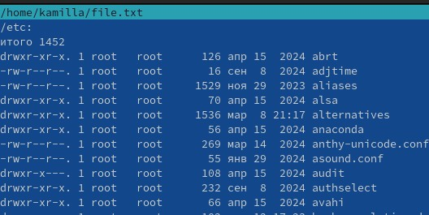

Содержимое текстового файла

## Выполнение лабораторной работы

Редактирую файл, выхожу, но не сохраняю изменения (рис. 7).

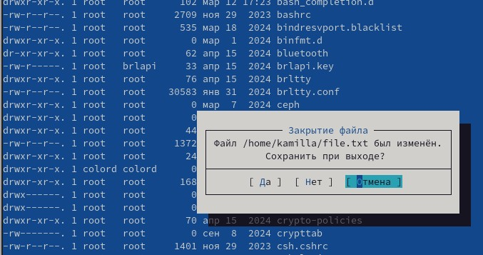

Редактирование файла

## Выполнение лабораторной работы

Создаю каталог (рис. 8).

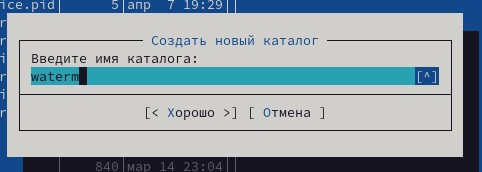

Создание каталога

## Выполнение лабораторной работы

Копирую файл в созданный каталог (рис. 9).

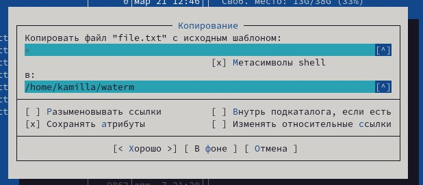

Копирование файлов

## Выполнение лабораторной работы

С помощью средств подменю Команда совершаю поиск файлов с расширением .txt (рис. 10).

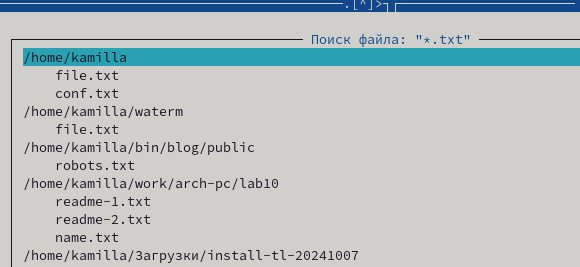

Поиск файлов

## Выполнение лабораторной работы

Перехожу в домашний каталог с помощью дерева каталогов (рис. 11).

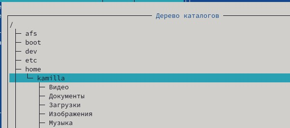

Переход в каталог

## Выполнение лабораторной работы

Анализ файла меню (рис. 13).

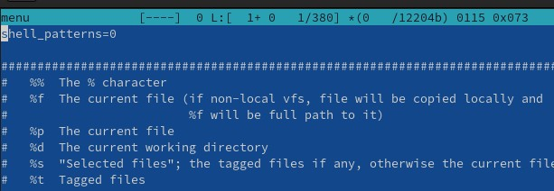

Анализ

## Выполнение лабораторной работы

Анализ файла расширений (рис. 14).

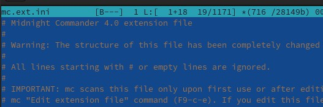

Анализ

## Выполнение лабораторной работы

Из подменю настройки вызвала окна настройки панели (рис. 15).

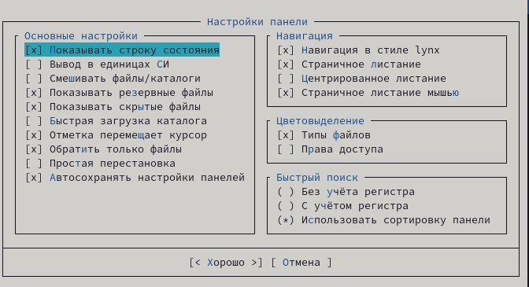

Настройки панели

## Выполнение лабораторной работы

настройки внешнего вида (рис. 16).

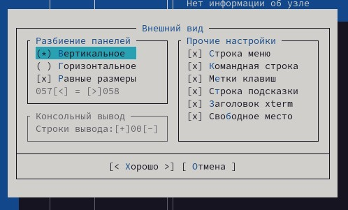

Настройки внешнего вида

## Выполнение лабораторной работы

настройки распознавания клавиш (рис. 17).

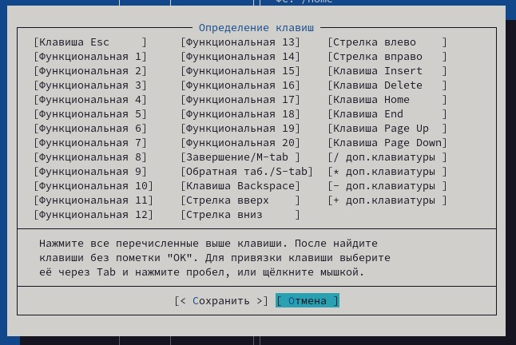

Настройки распознавания клавиш

## Выполнение лабораторной работы

параметры конфигурации (рис. 18).

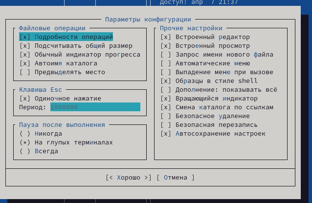

Параметры конфигурации

## Выполнение лабораторной работы

Клавишей F4 открыла файл для записи, добавила в него текст (рис. 20).

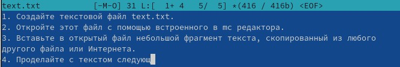

Открытие файла и запись в него

## Выполнение лабораторной работы

Удалила строку текста с помощью ctrl+y (рис. 21).

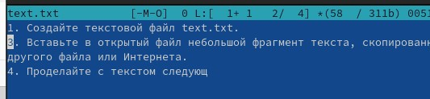

Удаление строки

## Выполнение лабораторной работы

Перемещаю выделенный текст с помощью клавиши F6 (рис. 22).

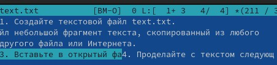

Перемещение выделенного текста

## Выполнение лабораторной работы

Сохраняю изменения в файле с помощью горячей клавиши F2 (рис. 23).

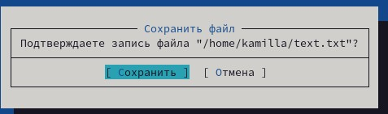

Сохранение изменений в файле

## Выполнение лабораторной работы

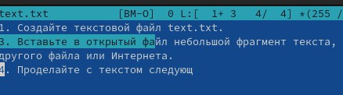

Отмена последнего действия

## Выполнение лабораторной работы

С помощью клавиш pgup pgdn у меня получилось попасть в начало и в конец файла соответственно, я добавила текст в начало и в конец файла (рис. 25).

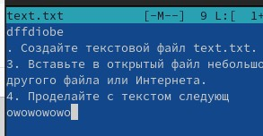

Добавление текста в начало и в конец файла

## Выполнение лабораторной работы

Горячая клавиша F10 закрывает файл, дополнительно спрашивая сохранить ли в нем несохраненные изменения, сохраняю и закрываю (рис. 26).

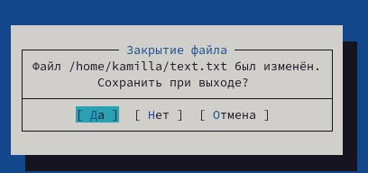

Закрытие файла с сохранением изменений

## Выполнение лабораторной работы

[figure not shown]

Текст файла с кодом с подсветкой

## Выводы

При выполнениии данной лабораторной работы я освоила основные возможности командной оболочки Midnight Commander, приобрела навыки практической работы по просмотру каталогов и файлов; манипуляций с ними